# Bioconductor Hand-on Training Data: Differential analysis of HiC data with diffHic

Hannah Coughlan

2018-11-30

# 1 Introduction

The following outlines a differential interaction analysis of HiC data. The purpose is to demonstrate the Bioconductor package diffHic (Lun & Smyth, BMC Bioinformatics, 2015)[https://doi.org/10.1186/s12859-015-0683-0]. For further information refer to the Bioconductor page: https://bioconductor.org/packages/release/bioc/html/diffHic.html. This tutorial will follow sections of the users guide.

The example data set we are using is from GEO GSE99151 (Johanson et al, Nature Immunology, 2018)[https://doi.org/10.1038/s41590-018-0234-8]. The dataset consists of three different mouse immune cell types collected from two different biological replicates. The aim of the analysis is to find lineage defining chromatin structure that is unique to the different cell types.

We will briefly cover the pre-processing of the HiC data (alignment of reads, processing the bam files and removal of artefacts) but we will concentrate on the differential analysis in R.

# 2 Pre-processing of the data

Here we will show example an example for processing HiC fastq files through to the input index file for the differential analysis pipeline.

The first step in the analysis is to align the fastq files to a reference genome with Bowtie2.

## 2.1 Producing a bam file

A significant proportion of a HiC library can be chimeric reads. Chimeric reads result from sequencing over the ligation junction between two restriction fragments. In other words, a chimeric read is from two distinct genomic loci. Therefore to accurately align such read pairs to the genome the ligation signature of the restriction enzyme (GATCGATC for MboI) is used to split chimeric reads with cutadapt. The read is split into two segments at the centre of the signature and each segment is then aligned separately to the reference genome using Bowtie2.

diffHic uses a python script to perform chimeric alignment by calling cutadapt and Bowtie2. The python script can be found at:

```r
system.file("python", "presplit_map.py", package="diffHic", mustWork=TRUE)
```

```
## [1] "C:/Program Files/R/R-3.5.1/library/diffHic/python/presplit_map.py"
```

To run the script the command is: python presplit_map.py -G ~/genome/mm10/bowtie2/mm10 -1 read1.fastq -2 read2.fastq –sig GATCGATC –cmd bowtie2 -o aligned.bam

Here -G is the path to the Bowtie2 index for the mm10 reference genome.

For the aligned bam file, the Picard software suite [https://broadinstitute.github.io/picard/] should be used to synchronize mate pair information, mark duplicate reads and sort the bam file by read name.

## 2.2 Mapping reads to restriction fragments

HiC is based on ligation of interacting DNA fragments after digestion with a restriction enzyme. The resolution of HiC data is inherently limited by the frequency of restriction sites and the size of the restriction fragments. Therefore we report the read alignment location in terms of the restriction fragment to which that read was mapped.

The restriction fragments can be obtained with the cutGenome function, as shown below for the mouse genome after digestion with the MboI restriction enzyme:

```r
library(diffHic)
library(BSgenome.Mmusculus.UCSC.mm10)
hs.frag<-cutGenome(BSgenome.Mmusculus.UCSC.mm10, "GATC",4)
hs.frag
```

```
## GRanges object with 6684545 ranges and 0 metadata columns:
##                   seqnames          ranges strand
##                      <Rle>       <IRanges>  <Rle>
##         [1]           chr1       1-3000194      *
##         [2]           chr1 3000191-3000816      *
##         [3]           chr1 3000813-3001051      *
##         [4]           chr1 3001048-3001122      *
##         [5]           chr1 3001119-3001798      *
##         ...            ...             ...    ...
##   [6684541] chrUn_JH584304     92982-97154      *
##   [6684542] chrUn_JH584304    97151-108839      *
##   [6684543] chrUn_JH584304   108836-109113      *
##   [6684544] chrUn_JH584304   109110-114452      *
##   [6684545] chrUn_JH584304   114449-114452      *
##   -------
##   seqinfo: 66 sequences from mm10 genome
```

We then store the restriction fragment in a Param object. This simplifies the coordinates of the analysis and we will use this object later in the analysis.

```r
hs.param<-pairParam(hs.frag)
hs.param
```

```
## Genome contains 6684545 restriction fragments across 66 chromosomes
## No discard regions are specified
## No limits on chromosomes for read extraction
## No cap on the read pairs per pair of restriction fragments
```

Next we will map aligned read pairs to a restriction fragment. The preparePairs functions converts the read position in the bam file into an index that points to a restriction fragment. The output is a HDF5 file that contains a pair of indices (anchors) for each read pair in a library. The HDF5 file contains a dataFrame for every combination of chromosomes in the reference genome.

We run the preparePairs functions on a bam file using the Param object and various flags. We can remove duplicate reads here (dedup=TRUE) and filter reads based on mapping quality score (minq).

```r
diagnostics <- preparePairs("aligned.bam", hs.param, file="hdf5_file.h5", dedup=TRUE, minq=10, chim.dist=800)
```

Along with the hdf5 file the function gives various diagnostics about the library. These values indicate the quality of the library. The different categories are:

```r
names(diagnostics)
## [1] "pairs" "same.id" "singles" "chimeras"
```

The pairs category shows how many read pairs were mapped to restriction fragments (mapped) and how many were removed as duplicates (marked).

```r
diagnostics$pairs
## total marked filtered mapped
## 7068675 103594 1532760 5460120
```

The same.id category is read pairs that have been mapped to the same restriction fragment and are considered artefacts (self-circles and dangling ends). Dangling ends are inward-facing read pairs mapped to the same fragment and are usually formed from sequencing of the unligated restriction fragments. Self-circles are outward-facing read pairs that are formed when two ends of the same restriction fragment ligate to one another. Both self-circles and dangling end reads are removed.

```r
diagnostics$same.id
## dangling self.circle
## 425219 138248
```

Chimeric reads are placed in their own category and have two separate alignments for each of the reads. Only the 5 prime end of the reads is used to determine the restriction fragment index. Invalid chimeric pairs are where the 3 prime end of the chimeric read disagrees with the mapping location of the 5 prime location of the other read mate. Invalid proportion can be used as an empirical measure of the mapping error rate and high error rates may be indicative of a fault in the mapping pipeline. In general, we will not remove the chimeric reads from the analysis.

```r
diagnostics$chimeras
## total mapped multi invalid
## 2495159 1725843 1040864 67989
```

## 2.3 Filtering libraries for artefacts

The prunePairs function removes read pairs that we suspect are additional artefacts.

```r
prunePairs("hdf5_file.h5", hs.param, file.out="hdf5_file_trimmed.h5", max.frag=700, min.inward=1000, min.outward=16000)

## total length inward outward retained
## 4896653 870339 94644 82964 3860024
```

The max.frag is the upper threshold for the inferred length of the sequencing fragment for a pair of reads. Large fragment lengths are indicative of off-site cleavage by the restriction enzyme. The length of the sequencing fragment is computed by summing the distance between the mapping location of the 5 prime end and the nearest restriction site on the 3 prime side for each read in the pair. A value for max.frag can be chosen by examining the distribution of inferred fragment lengths from getPairData:

```r
diags <- getPairData("hdf5_file.h5", hs.param)

hist(diags$length[diags$length < 1500], ylab="Frequency", xlab="Spacing (bp)", main="", col="grey80")
```

Refer to slides for plot.

The min.inward and min.outward threshold values remove read pairs based on insert size and on the strand orientation of the individual reads. The insert size is defined as the linear distance between two paired reads on the same chromosome and the strand orientation for a read pair refers to the combination of strands for the two alignments. The min.inward parameter removes inward-facing intra-chromosomal read pairs where the insert size is less than the specified value and the min.outward parameter does the same for outward-facing intra-chromosomal read pairs. These read pairs are technical artefacts that are (incorrectly) retained by preparePairs, as the two reads involved are mapped to different restriction fragments.

The min.inward and min.outward threshold values can be determined using strand orientation plots where we plot the distributions as a function of insert size.

```r
min.inward<- 1000
min.outward<- 16000

llinsert <- log2(diags$insert + 1L)
intra <- !is.na(llinsert)

breaks <- seq(min(llinsert[intra]), max(llinsert[intra]), length.out=30)
inward <- hist(llinsert[diags$orientation==1L], plot=FALSE, breaks=breaks)
outward <- hist(llinsert[diags$orientation==2L] ,plot=FALSE, breaks=breaks)
samestr <- hist(llinsert[diags$orientation==0L | diags$orientation==3L], plot=FALSE, breaks=breaks)
samestr$counts <- samestr$counts/2

ymax <- max(inward$counts, outward$counts, samestr$counts)/1e6
xmax <- max(inward$mids, outward$mids, samestr$mids)
xmin <- min(inward$mids, outward$mids, samestr$mids)

plot(0,0,type="n", xlim=c(xmin, xmax), ylim=c(0, ymax),xlab=expression(log[2]~"[insert size (bp)]"), ylab="Frequency (millions)")
lines(inward$mids, inward$counts/1e6, col="darkgreen", lwd=2)
abline(v=log2(min.inward), col="darkgrey")
lines(outward$mids, outward$counts/1e6, col="red", lwd=2)
abline(v=log2(min.outward), col="darkgrey", lty=2)
lines(samestr$mids, samestr$counts/1e6, col="blue", lwd=2)
legend("topright", c("inward", "outward", "same"), col=c("darkgreen", "red", "blue"), lwd=2)
```

Refer to slides for plot.

If different pieces of DNA were randomly ligated together, one would expect to observe equal proportions of all strand orientations ( +/+, -/-, +/- and -/+). At high insert sizes, the distributions converge for all strand orientations which is consistent with random ligation between two separate restriction fragments. At lower insert sizes, spikes are observed in the outward (sometimes) and inward distributions due to self circularisation and dangling ends. Thresholds should be chosen in prunePairs to remove these spikes.

Finally, we can merge ant technical replicates into a single library with the mergePairs function.

# 3 Data exploration

Now we have hdf5 libraries that have been processed for artefacts and technical replicates merged. We can move onto the analysis. This workflow is a good starting point for an analysis but as every dataset is unique each analysis will need to be unique. Filtering and bin size are often parameters that need to be explored.

## 3.1 The targets file

The first step to make the analysis easier to follow, is to create a targets dataframe which contains information about the sequenced libraries.

```r
library<-c("CD4T1","CD4T2","GW1","GW2","MATB1","MATB2")
group<-c("CD4T","CD4T","Gran","Gran","MB","MB")
files<-paste0("data/",library, ".h5")
targets<-data.frame(library,group, files)
targets
```

```
##   library group         files
## 1   CD4T1  CD4T data/CD4T1.h5
## 2   CD4T2  CD4T data/CD4T2.h5
## 3     GW1  Gran   data/GW1.h5
## 4     GW2  Gran   data/GW2.h5
## 5   MATB1    MB data/MATB1.h5
## 6   MATB2    MB data/MATB2.h5
```

We are also are now going to load in some data objects that we will use in our analysis as they will take a few hours to generate from the beginning. I have included the command to generate the objects in the analysis.

```r
load("data/diffHic_tutorial.RData")
```

## 3.2 Counting the read pair data into interactions

Before analysis, the read pairs in a each HiC library must be summarised into a count for each interaction. This count is used as an experimental measure of the interaction intensity. Each pairwise interaction is parameterised by two genomic intervals (anchors) representing the interacting loci. The count for that interaction is defined as the number of read pairs with one read mapping to each of the intervals.

To counts the hdf5 files into bins we use the param index. However first we will restrict the param object to only chromosomes of interest (i.e. exclude the mitochondrial genome and unassigned contigs). We also wish to exclude blacklisted regions according to the ENCODE blacklist for mm10 [https://sites.google.com/site/anshulkundaje/projects/blacklists]. This object was already loaded into the workspace.

```r
chrom <- sprintf('chr%s',c(1:19,"X","Y"))
hs.param <- reform(hs.param,restrict=chrom, discard=blacklist)
hs.param
```

```
## Genome contains 6684545 restriction fragments across 66 chromosomes
## 164 regions specified in which alignments are discarded
## Read extraction is limited to 21 chromosomes
## No cap on the read pairs per pair of restriction fragments
```

Now we partition the genome into contiguous non-overlapping bins of constant size where we define each interaction as a pair of bins (anchors). Counting of the read pairs between the anchors is performed for multiple libraries using the squareCounts function:

```r
bin.size <- 100e3
data<-squareCounts(targets$files, hs.param, width=bin.size, filter=10, restrict.regions = TRUE)
```

Here the bin width is defined as 100 kbp and a filter of 10 is used which will remove as pairwise interactions that are less than 10 counts. Again we have already loaded the data object into the workspace as this step takes ~30 minutes.

```r
bin.size <- 100e3
data
```

```
## class: InteractionSet
## dim: 9804070 6
## metadata(2): param width
## assays(1): counts
## rownames: NULL
## rowData names(0):
## colnames: NULL
## colData names(1): totals
## type: ReverseStrictGInteractions
## regions: 24067
```

This generates an InteractionSet object containing information for multiple genomic interactions were each row corresponds to an interaction (bin pair):

```r
head(interactions(data))
```

```
## ReverseStrictGInteractions object with 6 interactions and 0 metadata columns:
##       seqnames1         ranges1     seqnames2         ranges2
##           <Rle>       <IRanges>         <Rle>       <IRanges>
##   [1]      chr1 3000191-3099537 ---      chr1 3000191-3099537
##   [2]      chr1 3099534-3198805 ---      chr1 3000191-3099537
##   [3]      chr1 3099534-3198805 ---      chr1 3099534-3198805
##   [4]      chr1 3198802-3299787 ---      chr1 3000191-3099537
##   [5]      chr1 3198802-3299787 ---      chr1 3099534-3198805
##   [6]      chr1 3198802-3299787 ---      chr1 3198802-3299787
##   -------
##   regions: 24067 ranges and 1 metadata column
##   seqinfo: 66 sequences from mm10 genome
```

We can also access each of the anchors:

```r
head(anchors(data, type="first"))
```

```
## GRanges object with 6 ranges and 1 metadata column:
##       seqnames          ranges strand |    nfrags
##          <Rle>       <IRanges>  <Rle> | <integer>
##   [1]     chr1 3000191-3099537      * |       315
##   [2]     chr1 3099534-3198805      * |       295
##   [3]     chr1 3099534-3198805      * |       295
##   [4]     chr1 3198802-3299787      * |       288
##   [5]     chr1 3198802-3299787      * |       288
##   [6]     chr1 3198802-3299787      * |       288
##   -------
##   seqinfo: 66 sequences from mm10 genome
```

```r
head(anchors(data, type="second"))
```

```
## GRanges object with 6 ranges and 1 metadata column:
##       seqnames          ranges strand |    nfrags
##          <Rle>       <IRanges>  <Rle> | <integer>
##   [1]     chr1 3000191-3099537      * |       315
##   [2]     chr1 3000191-3099537      * |       315
##   [3]     chr1 3099534-3198805      * |       295
##   [4]     chr1 3000191-3099537      * |       315
##   [5]     chr1 3099534-3198805      * |       295
##   [6]     chr1 3198802-3299787      * |       288
##   -------
##   seqinfo: 66 sequences from mm10 genome
```

The assay entry contains a matrix of counts for each interaction where each column represents a library:

```r
head(assay(data))
```

```
##      [,1] [,2] [,3] [,4] [,5] [,6]
## [1,]  311  366  556  409  326  370
## [2,]  159  202  243  201  191  201
## [3,]  284  381  534  419  312  370
## [4,]   67   98  115   92   77  109
## [5,]  178  273  285  205  193  252
## [6,]  359  491  629  526  400  448
```

The object also contains the total number of read pairs for each library:

```r
data.frame(File=targets$library, Total=data$totals)
```

```
##    File     Total
## 1 CD4T1 112094770
## 2 CD4T2 153424314
## 3   GW1 140970920
## 4   GW2 108556910
## 5 MATB1 109284271
## 6 MATB2 132703204
```

The squareCounts functions has multiple arguments for changing the analysis. We use restrict.regions = TRUE to exclude the regions we set up in the param object. The filter option removes any interactions (a row of the count matrix) where the sum across the row is below this threshold. Most likely, low count numbers are uninformative and this greatly reduces the size of the InteractionSet object.

The most important parameter for the entire analysis is the width argument which is the bin size. This determines the spatial resolution of the analysis and the features that we are likely to find. Small bins have great spatial resolution, however if the libraries were not sequenced deeply enough the counts of the interactions will be too low to have statistical power and capture features of the chromatin.

```r
head(regions(data))
```

```
## GRanges object with 6 ranges and 1 metadata column:
##       seqnames          ranges strand |    nfrags
##          <Rle>       <IRanges>  <Rle> | <integer>
##   [1]     chr1       1-3000194      * |         1
##   [2]     chr1 3000191-3099537      * |       315
##   [3]     chr1 3099534-3198805      * |       295
##   [4]     chr1 3198802-3299787      * |       288
##   [5]     chr1 3299784-3400047      * |       260
##   [6]     chr1 3400044-3499982      * |       260
##   -------
##   seqinfo: 66 sequences from mm10 genome
```

1 Mpb will capture broad features and is a good place to start. Here we will use 100 kbp as the libraries are over 100 million reads.

## 3.3 Filtering interactions

Filtering is performed to remove uninteresting interactions. This will decrease the need for computational resources, decrease the effect of multiplicity correction and increase the power of the analysis. There are multiple strategies for filtering HiC data that are outliers in the diffHic users guide. Here we will show an approach that aims to remove low abundance interactions.

The simplest definition of an “uninteresting” interaction is that resulting from non-specific ligation. These are represented by low-abundance bin pairs where no underlying contact is present to drive ligation between the corresponding bins. The magnitude of non-specific ligation is empirically estimated by assuming that most interchromosomal contacts are not genuine. The median abundance across inter-chromosomal bin pairs is used as an estimate of the non-specific ligation rate.

The filter threshold is estimated from the inter-chromosomal interactions of a larger bin dataset with no prior filtering. The larger counts produce a more precise estimate of the uninteresting ligation.

```r
background <- squareCounts(targets$files, hs.param, width=1e6)
```

We already have this object in the workspace.

We then use the filterDirect function to filter our data using the larger bin dataset as a reference.

```r
direct <- filterDirect(data, reference=background)
direct$threshold
```

```
## [1] -5.92523
```

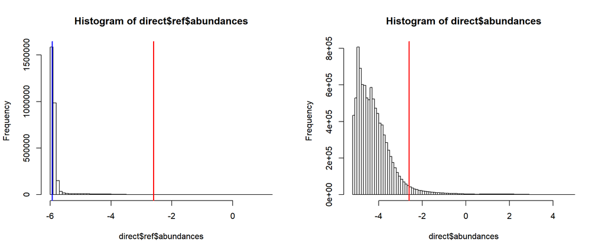

```r
par(mfrow=c(1,2))
hist(direct$ref$abundances, breaks=100)
abline(v=direct$ref$threshold, lwd=2, col="blue") # Background estimate
abline(v=direct$ref$threshold+log2(10), lwd=2, col="red") # Threshold

hist(direct$abundances, breaks=100)
abline(v=direct$ref$threshold+log2(10), lwd=2, col="red") # Threshold
```

We can now see how many bin pairs will be retained:

```r
high.ab <- direct$abundances > direct$threshold +log2(10)
summary(high.ab)
```

```
##    Mode   FALSE    TRUE
## logical 9366484  437586
```

We will now filter the data by subsetting the data object. We also filter out the diagonal elements (pairs in the same bin) as these bins typically contain artefacts.

```r
keep <- high.ab & filterDiag(data, by.diag=1L)
data <- data[keep,]
sum(keep)
```

```
## [1] 390033
```

This is just one method of filtering HiC data which I have found to be a good general approach.

## 3.4 Normalisation

Many different methods of normalisation can be explored to remove biases in the HiC data. It is important to remember that this is a differential type analysis therefore we do not need to correct the counts. Instead diffHic computes offsets that are used in fitting generalised linear models (GLMs) to the data.

Trended biases can be introduced to the libraries through the complicated experimental protocol of HiC (such as cross-linking efficiency, ligation). Scalling methods such TMM normalisation are too simplistic to deal with the complex biases observed in real HiC data.

Trended biases can inflate the variance estimates or fold-changes for some pairs. These type of biases can be eliminated with a non-linear normalisation and here we will use LOESS normalisation. The normOffsetrs function from the csaw package is used to compute an offset term for each bin pair in each library.

Later in the analysis we will fit a GLM to the counts, a large offset for a bin pair in a library is equivalent to downscaling the corresponding count relative to the counts of other libraries. The matrix of offsets has the same dimensions as the count matrix and is stored as an element of the assays slot of the InteractionSet object.

```r
library(csaw)
data.offs <- normOffsets(data, type="loess")
head(assay(data.offs,2))
```

```
##            [,1]      [,2]       [,3]       [,4]        [,5]      [,6]
## [1,] -0.1423144 0.1593653 0.06629814 -0.2038614 -0.02438773 0.1449001
## [2,] -0.1550016 0.1581234 0.05670168 -0.2074220 -0.02108658 0.1686851
## [3,] -0.1439098 0.1591943 0.06594824 -0.2032168 -0.02462805 0.1466121
## [4,] -0.1597166 0.1578984 0.05018180 -0.2122177 -0.01818737 0.1820414
## [5,] -0.1529547 0.1586039 0.05976189 -0.2050685 -0.02282370 0.1624811
## [6,] -0.1357026 0.1603755 0.06761682 -0.2075461 -0.02274360 0.1380000
```

Trended biases in the data can manifest as an abundance dependent trend in a MA plots between libraries. By viewing a plot before and after normalisation the success of the process can be assessed.

```r
library(edgeR)
```

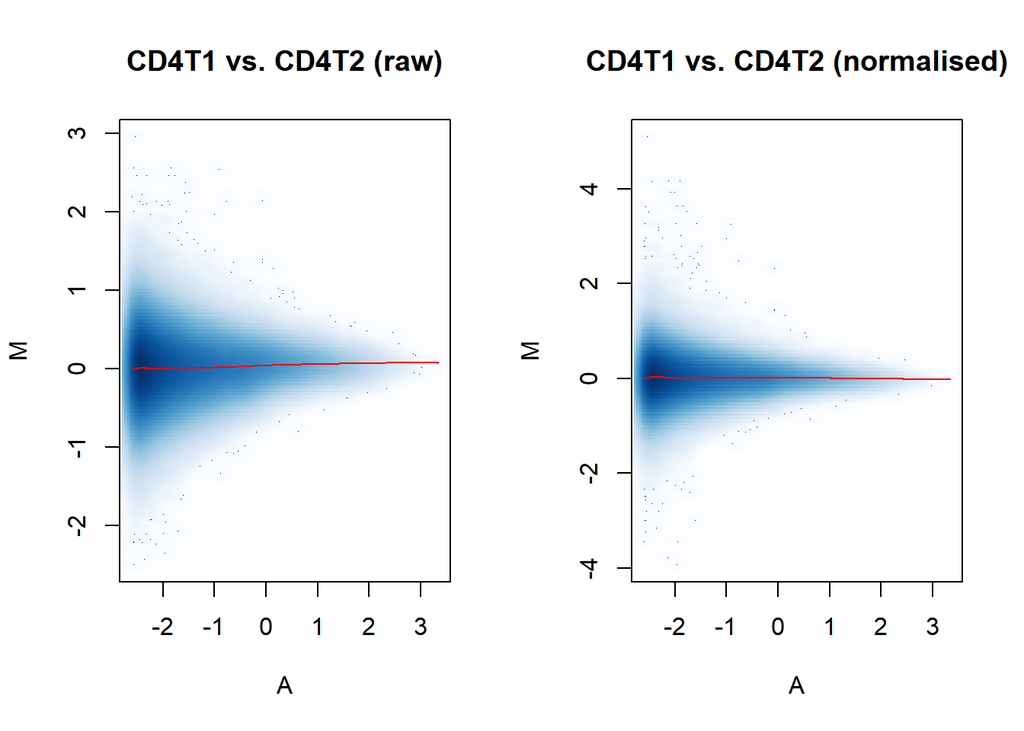

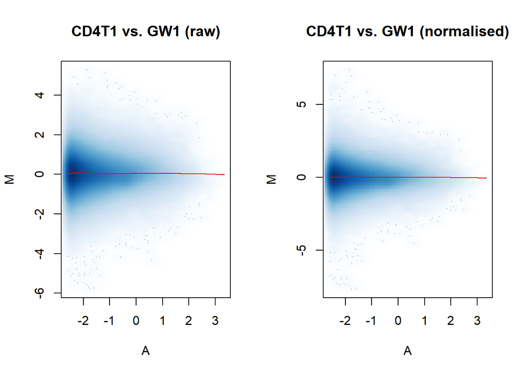

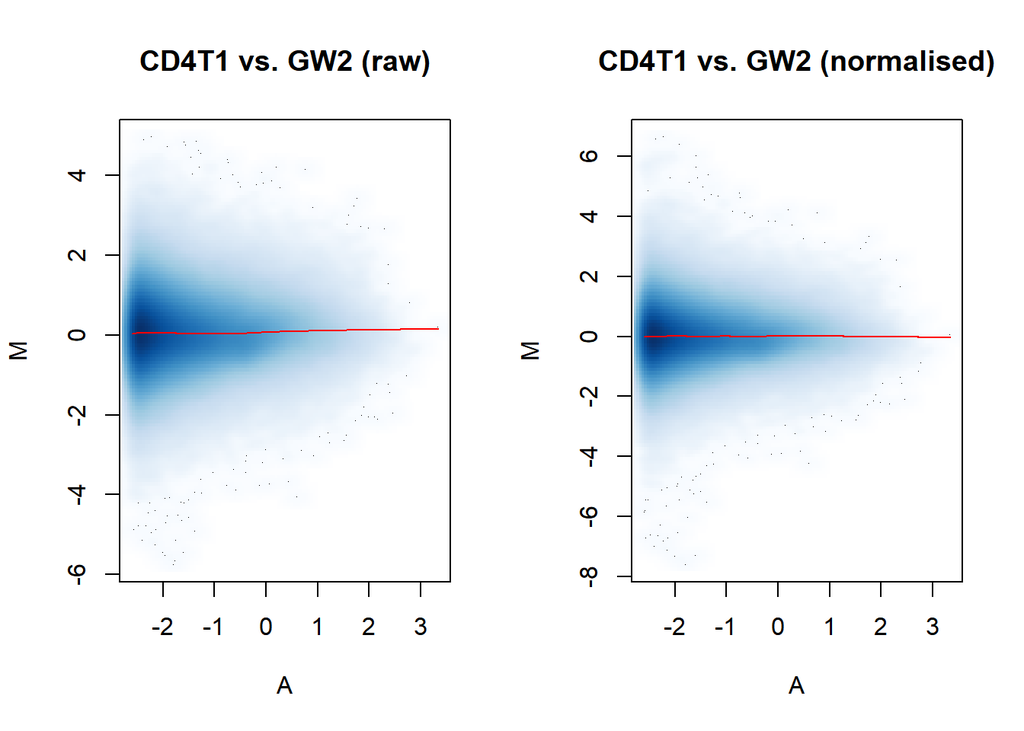

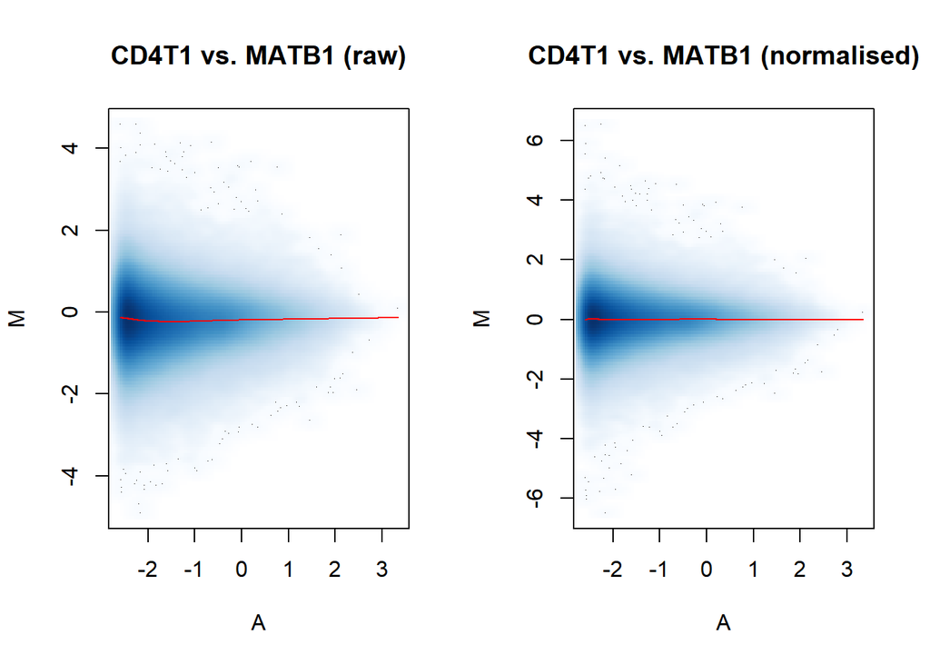

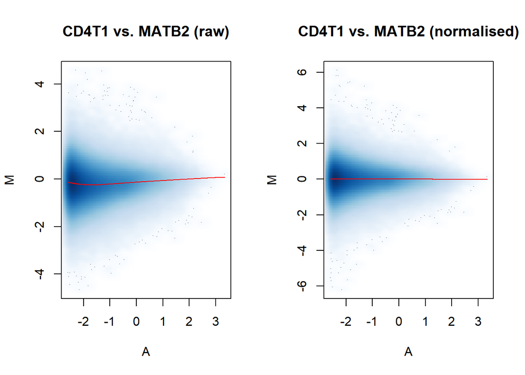

```r
ab <- aveLogCPM(asDGEList(data))
o <- order(ab)
adjc <- cpm(asDGEList(data), log=TRUE)
normc <- log2(assay(data.offs,1)+0.5) - assay(data.offs,2)/log(2)
lib.names <- targets$library
for (lib in c(2:6)) {
    par(mfrow=c(1,2))
    for (mode in c("raw", "normalised")) {
        if (mode=="raw") {
            adj.counts <- adjc
        } else {
            adj.counts <- normc
        }
        mval <- adj.counts[,1]-adj.counts[,lib]
        smoothScatter(ab, mval, xlab="A", ylab="M", cex=0.5, main=sprintf("%s vs. %s (%s)",
            lib.names[1], lib.names[lib], mode))
        lfit <- loessFit(x=ab, y=mval)
        lines(ab[o], lfit$fitted[o], col="red")
    }
}
```

Here we can see the normalisation has been successful as the trended biases have been removed.

We can now create a DGEList object from the InteractionSet object that we will use for the rest of the analysis. We will also add sample labels.

```r
y <- asDGEList(data.offs)
rownames(y$samples)<-targets$library
colnames(y$counts)<-targets$library
y$samples$group<-targets$group
levels(y$samples$group)<-unique(y$samples$group)
y
```

```
## An object of class "DGEList"
## $counts
##   CD4T1 CD4T2 GW1 GW2 MATB1 MATB2
## 1    67    98 115  92    77   109
## 2    49    68  81  48    42    74
## 3    61   100 100  83    89   103
## 4    38    60  71  34    36    42
## 5    34    87  92  55    70    64
## 390028 more rows ...
##
## $samples
##       group  lib.size norm.factors
## CD4T1  CD4T 112094770            1
## CD4T2  CD4T 153424314            1
## GW1    Gran 140970920            1
## GW2    Gran 108556910            1
## MATB1    MB 109284271            1
## MATB2    MB 132703204            1
##
## $offset
##          [,1]     [,2]     [,3]     [,4]     [,5]     [,6]
## [1,] 18.50160 18.80328 18.71022 18.44006 18.61953 18.78882
## [2,] 18.48892 18.80204 18.70062 18.43650 18.62283 18.81260
## [3,] 18.50001 18.80311 18.70987 18.44070 18.61929 18.79053
## [4,] 18.48420 18.80182 18.69410 18.43170 18.62573 18.82596
## [5,] 18.49096 18.80252 18.70368 18.43885 18.62109 18.80640
## 390028 more rows ...
```

## 3.5 Unsupervised clustering

An effective method to explore the data is with a multi-dimensional scaling plot (MDS). The function plotMDS from the limma package draws a MDS plot of the samples in which distances correspond to leading log-fold-changes between each pair of samples. The leading log-fold-change is the average (root-mean-square) of the largest absolute log-fold changes between each pair. This plot can be viewed as a type of unsupervised clustering. Here we plot an MDS for the normalised cpms for the top 50,000 bins:

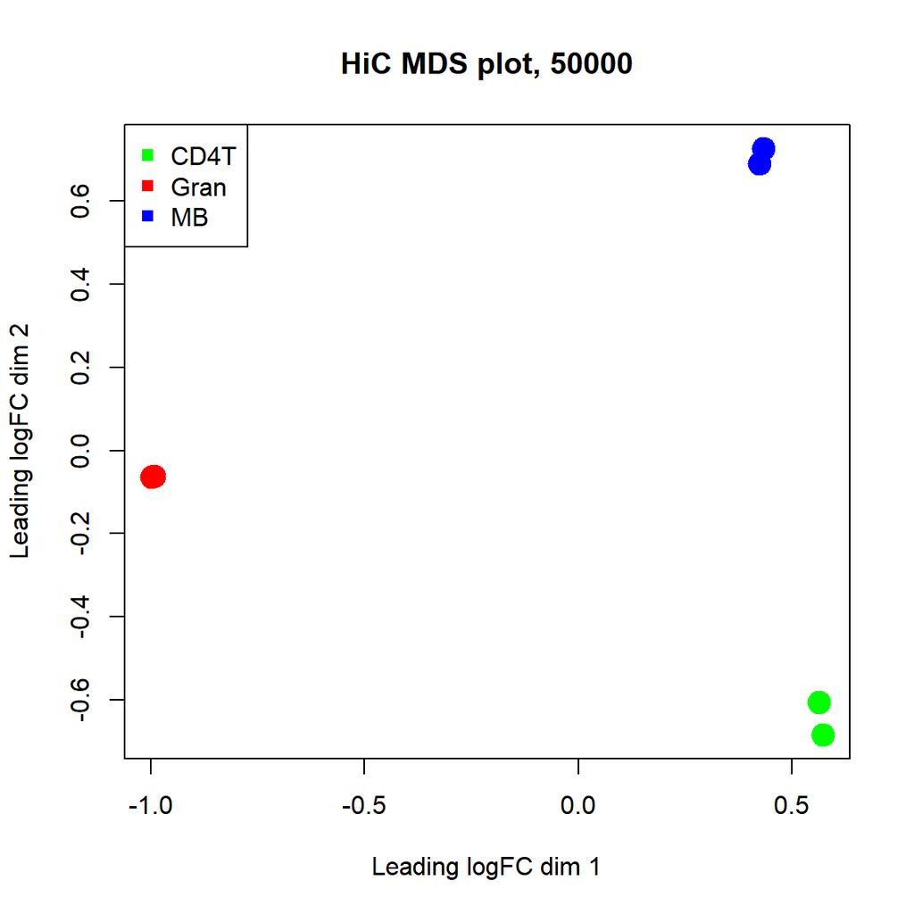

```r
par(mfrow=c(1,1))
group.col <-c("green","green","red","red","blue","blue")
plotMDS(normc, col=group.col,pch = as.numeric(19), top=50000, cex=2, dim.plot = c(1,2), main = "HiC MDS plot, 50000")
legend("topleft", legend = unique(group), col =unique(group.col), pch = as.numeric(15), cex=1.0, title.col = "black")
```

We can see the samples are separated by cell type with the biological replicates clustering together.

# 4 Differential analysis

We now move onto the differential analysis of the dataset. The differential analysis in diffHic is based on the statistical framework in the edgeR package (Robinson et al, Bioinformatics, 2010). I recommend reading the edgeR user guide for more information on the individual functions [https://bioconductor.org/packages/release/bioc/vignettes/edgeR/inst/doc/edgeRUsersGuide.pdf] and reading the diffHic paper for a general overview of the modelling.

The differential analysis has three main steps: estimating the variability in the data, fitting a GLM to the counts and performing testing for significant differences between the bin pairs.

## 4.1 The design matrix

The differential analysis requires a design matrix that mathematically represents the design of the experiment. It is used to specify the linear models required for the differentially expression analysis.

```r
design <- model.matrix(~0 + group)
rownames(design) <- targets$library
design
```

```
##       groupCD4T groupGran groupMB
## CD4T1         1         0       0
## CD4T2         1         0       0
## GW1           0         1       0
## GW2           0         1       0
## MATB1         0         0       1
## MATB2         0         0       1
## attr(,"assign")
## [1] 1 1 1
## attr(,"contrasts")
## attr(,"contrasts")$group
## [1] "contr.treatment"
```

## 4.2 Modelling technical and biological variation

An estimation of the variation in the bin pairs is used during testing to reduce the significance of any detected differences when the counts are highly variable for a given bin pair. The variability of the bin pair counts between replicate samples is modelled using the quasi-likelihood (QL) methods implemented in the edgeR package. The counts are assumed to follow quasi-negative-binomial distributions i.e., they are negative binomial (NB) distributed with an additional technical overdispersion parameter. So we end up with a bin pair dispersion that has two components: the NB dispersion (biological coefficient of variation) and the QL dispersion (technical variation). We estimate both in two steps.

The biological coefficient of variation (BCV) is estimated by fitting an abundance-dependent trend to the NB dispersions across all bin pairs. The NB dispersions represent the level of biological variability between replicates and the square root of NB dispersions is the BCV, i.e., the coefficient of variation with which the count for each bin pair varies between the replicate samples, averaged over bin pairs with similar abundances. It represents the coefficient of variation that would be observed in the counts if the sequencing depth was sufficiently large (i.e. no technical variation).

We estimate the NB dispersions with the estimateDisp function with robust=TRUE to protect from outliers.

```r
dispersion <- estimateDisp(y, design,robust=TRUE)
```

The BCV is then determined from the overall dispersion as:

```r
BCV <- sqrt(dispersion$common.dispersion)
BCV
```

```
## [1] 0.03734624
```

This is a reasonable BCV for HiC data. We can also visualise the BCV for every bin pair and examine the trend as a function of abundance.

A plot of the average $\log_2$-count per million (CPM) versus the BCV for each bin pair is shown below. This plot visualises how bin pair variation changes between replicate samples changes as abundance increases. Ideally we want the BCV to decrease as abundance increases.

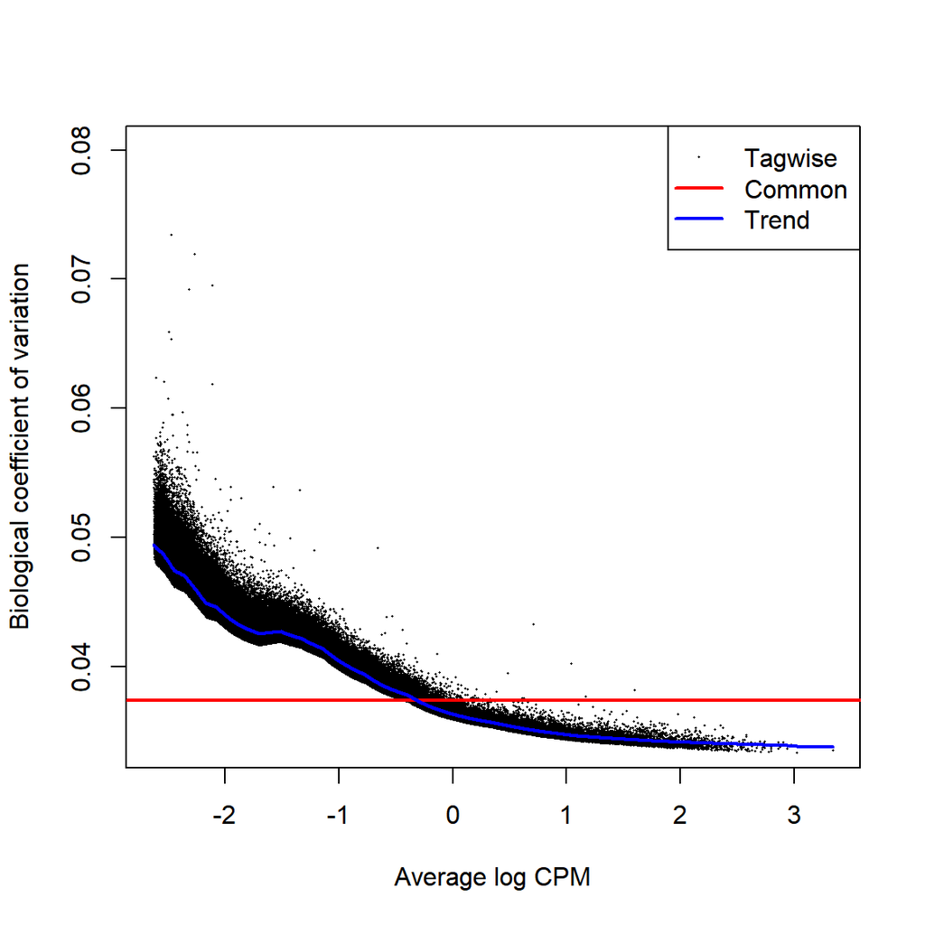

```r
par(mfrow=c(1,1))
plotBCV(dispersion, ylim=c(0.034,0.08))
```

The QL dispersion is estimated in the GLM fitting which we will now perform.

## 4.3 Fitting the GLM

Counts for each bin pair are modelled using the GLM methods implemented in the edgeR package and takes into account the sequencing depth and the normalisation offsets we calculated previously.

The QL dispersion for each bin pair is estimated from the deviance of the fitted GLM. The QL dispersion can account for heteroskedasticity between bin pairs. QL dispersion is estimated with the glmQLFit. The information is shared between bin pairs using an empirical Bayes (EB) approach. Per-bin pair QL estimates are shrunk towards a common trend across all bin pairs. Again, it is important to use the robust=TRUE argument as this protects against any large outliners.

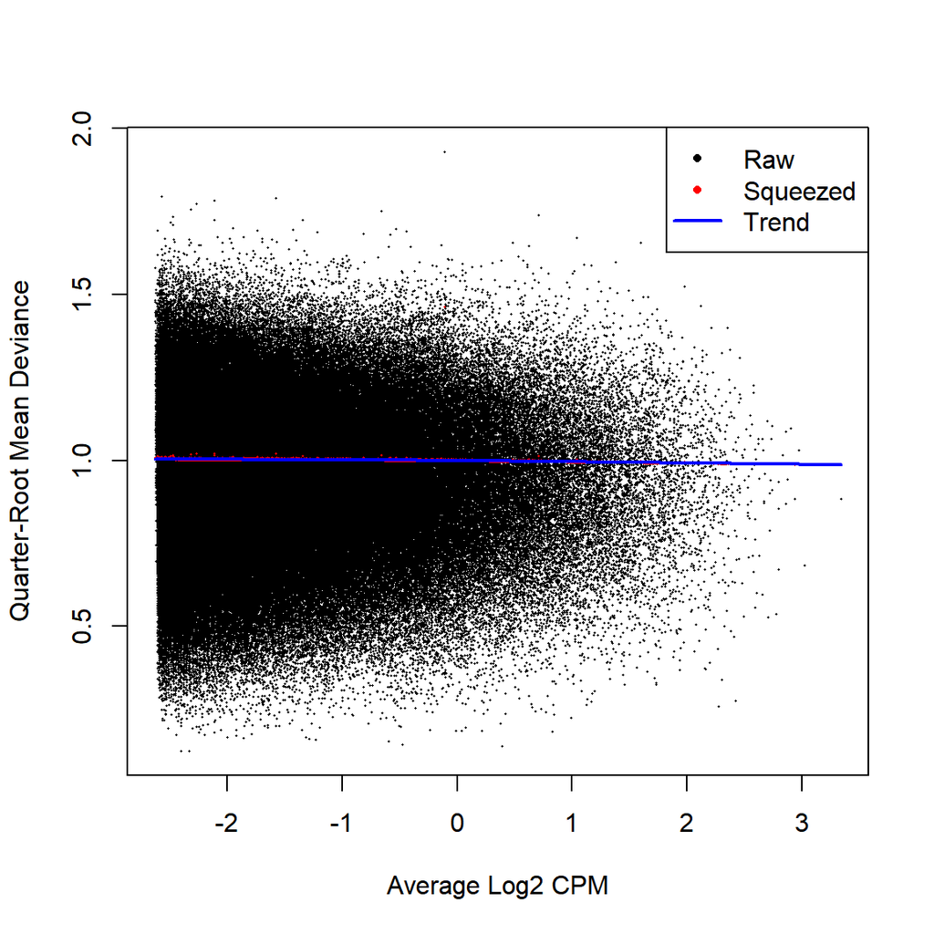

```r
par(mfrow=c(1,1))
fit <- glmQLFit(dispersion, design, robust=TRUE)
plotQLDisp(fit)
```

Now that we have modelled the counts, we can move onto the testing between groups.

## 4.4 Testing for significant differential interactions

Here we will look at the differences between each sample using the QL fit performed previously. Using the glmQLFTest function, a QL F-test is performed for each bin pair to identify significant differences.

In a diffHic analysis, many bin pairs are tested for signifcant differences across the interaction space (100s of 1000s). Correction for multiple testing is neccessary to avoid excessive detection of spurious differences. For genome wide analyses, this correction is typically performed by controlling the false discovery rate (FDR) with the Benjamini-Hochberg (BH) method. Here we will set an FDR cut-off as 0.05.

Before we can perform the tests, we need to set up the contrasts between the different groups. What do we want to test?

```r
contrast=makeContrasts(TvsMB=c(1,0,-1),
                       TvsG=c(1,-1,0),
                       MBvsG=c(0,-1,1), levels=design)

contrast
```

```
##            Contrasts
## Levels      TvsMB TvsG MBvsG
##   groupCD4T     1    1     0
##   groupGran     0   -1    -1
##   groupMB      -1    0     1
```

```r
contrast=makeContrasts(TvsMB=groupCD4T-groupMB,
                       TvsG=groupCD4T-groupGran,
                       MBvsG=groupMB-groupGran, levels=design)
contrast
```

```
##            Contrasts
## Levels      TvsMB TvsG MBvsG
##   groupCD4T     1    1     0
##   groupGran     0   -1    -1
##   groupMB      -1    0     1
```

### 4.4.1 Differential interactions between CD4+ T cells and mature B cells

First we will test for differences between the T cells and the B cells. We will then use the topTags functions to adjust the p-value for multiple testing.

```r
results.CD4T.vs.MB <- glmQLFTest(fit, contrast=contrast[,"TvsMB"])
di.CD4T.vs.MB <- topTags(results.CD4T.vs.MB, sort.by="none", n=Inf)$table
is.di <- di.CD4T.vs.MB$FDR <= 0.05

summary(is.di)
```

```
##    Mode   FALSE    TRUE
## logical  294388   95645
```

Interpretation of the individual DIs is complicated by spatial dependencies between adjacent bin pairs in features such as TADs. If many adjacent bin pairs were separately reported as DIs, this would lead to unnecessary redundancy in the results. To mitigate this effect, adjacent bin pairs can be aggregated into larger clusters to reduce redundancy. However care needs to be taken when controlling the FDR for the whole cluster.

The FDR across clusters is not the same as that across bin pairs. The former is more useful as the results are usually interpreted in terms of clusters, where each cluster corresponds to one interaction event. However, the FDR across bin pairs is easier to control by applying the BH method directly to the bin pair p-values. Treating the FDR across bin pairs as that across clusters is usually inappropriate and results in loss of FDR control. The diffHic package provides several methods for controlling the FDR.

I will show a strategy which is recommended for a routine analysis that is based on clustering significant bin pairs.

### 4.4.2 Clustering of the differential interactions

We will perform the controlling of the FDR based on the clustering based on significant bin pairs. Here the interaction space is often dominated by high-abundance structural features like domains and compartments. In such high-density areas, too many bin pairs may be retained after independent filtering on abundance.

The diClusters function only clusters those bin pairs that are significantly different and attempts to control the cluster level FDR below target=0.05. For further details on the cluster level FDR refer to the diffHic users guide.

```r
cluster.CD4T.vs.MB <- diClusters(data[,c(1,2,5,6)], results.CD4T.vs.MB$table, target=0.05, cluster.args=list(tol=1, upper=bin.size*10))

length(cluster.CD4T.vs.MB$interactions)
```

```
## [1] 13952
```

```r
head(cluster.CD4T.vs.MB$interactions)
```

```
## ReverseStrictGInteractions object with 6 interactions and 0 metadata columns:
##       seqnames1           ranges1     seqnames2           ranges2
##           <Rle>         <IRanges>         <Rle>         <IRanges>
##   [1]      chr1   6899877-7199820 ---      chr1   6600004-6999652
##   [2]      chr1   8700025-8899486 ---      chr1   7499447-7800129
##   [3]      chr1 11299832-11600002 ---      chr1 10900412-11200274
##   [4]      chr1 12500155-12900028 ---      chr1 11400574-12000439
##   [5]      chr1 12999879-14100215 ---      chr1 12599874-13599853
##   [6]      chr1 13800245-14100215 ---      chr1 13599850-13900076
##   -------
##   regions: 19915 ranges and 0 metadata columns
##   seqinfo: 66 sequences from mm10 genome
```

We have now reduced the number of DIs we are reporting, however, the DIs will now be of varying size.

The identities of the bin pairs in each cluster are returned in the indices field of the output:

```r
head(cluster.CD4T.vs.MB$indices[[1]][!is.na(cluster.CD4T.vs.MB$indices[[1]])], n=200)
```

```
##   [1] 147 148 149 150 151 152 153 154 155 156 156 157 158 157 157 157 157
##  [18] 157 157   1   1   1   1   1   1 159 160 161 162 163 164 164 164 164
##  [35] 165 166 166 166 166 166 166 167   2   2   2 168 169 170 171 172 173
##  [52] 174 172 174 175 176 177 178 179 179 180 180 180 180 180 180   3   3
##  [69]   3   3 181 182 182   4   4   4   4   4 183   4   4   4 184   4   5
##  [86]   5   5   5   5   5   5   5   5   5   5   5   5   5   5   5   5   5
## [103]   5   5   5   5   5   5   5   5 185   5   5   5   5   5   5   6 185
## [120] 185   5   5   5   5   5   6   6 185   5   5   5   5   5   6   6   6
## [137] 185   7   7   7   7   7   8   8   8   8   7   7   7   7   7   8   8
## [154]   8   8   8   7   7   7   7   7   7   8   8   8   8   8   8   7   7
## [171]   7   7   7   8   8   8   8   8   8   8   7   7   7   7   7   7   7
## [188]   8   8   8   8   8   8   8   8   7   7   7   7   7
```

Indices can be used to compute additional statistics for each cluster using the combineTests and getBestTest functions in csaw. getBestTest will identify the bin pair in the cluster with the lowest p-value, which is useful for finding the strongest changes in large clusters. Users are advised to ignore the p-value and FDR fields as these assume independent clustering. The combined p-value from combineTests is stored but is only used for sorting and should not be interpreted as a significance measure. We combine all the important statistics.

```r
tabcom <- combineTests(cluster.CD4T.vs.MB$indices[[1]], results.CD4T.vs.MB$table)
tabbest <- getBestTest(cluster.CD4T.vs.MB$indices[[1]], results.CD4T.vs.MB$table)

tabstats <- data.frame(tabcom[,-5], logFC=tabbest$logFC, FDR=cluster.CD4T.vs.MB$FDR)
results.CD4T.vs.MB <- cbind(as.data.frame(as.data.frame(cluster.CD4T.vs.MB$interactions)[,c(1:3, 6:8)]), tabstats)

head(results.CD4T.vs.MB)
```

```
##   seqnames1   start1     end1 seqnames2   start2     end2 nWindows
## 1      chr1  6899877  7199820      chr1  6600004  6999652        6
## 2      chr1  8700025  8899486      chr1  7499447  7800129        3
## 3      chr1 11299832 11600002      chr1 10900412 11200274        4
## 4      chr1 12500155 12900028      chr1 11400574 12000439        9
## 5      chr1 12999879 14100215      chr1 12599874 13599853       42
## 6      chr1 13800245 14100215      chr1 13599850 13900076        6
##   logFC.up logFC.down       PValue direction      logFC      FDR
## 1        0          5 2.084271e-10      down -0.9804638 0.049957
## 2        0          3 1.584183e-04      down -1.1827494 0.049957
## 3        4          0 1.681635e-05        up  0.7071338 0.049957
## 4        0          9 2.448888e-05      down -1.2501048 0.049957
## 5        5         32 3.944071e-21      down -1.2914872 0.049957
## 6        0          6 6.515723e-22      down -1.1933841 0.049957
```

We create an object with all the stats in it:

```r
is.sig <- !is.na(cluster.CD4T.vs.MB$indices[[1]])
cluster.CD4T.vs.MB$indices[[1]] <- cluster.CD4T.vs.MB$indices[[1]][is.sig]
cluster.CD4T.vs.MB$data <- data[is.sig,c(1,2,5,6)]
mcols(cluster.CD4T.vs.MB$interactions) <- cbind(mcols(cluster.CD4T.vs.MB$interactions), tabstats)

head(cluster.CD4T.vs.MB$interactions)
```

```
## ReverseStrictGInteractions object with 6 interactions and 7 metadata columns:
##       seqnames1           ranges1     seqnames2           ranges2 |
##           <Rle>         <IRanges>         <Rle>         <IRanges> |
##   [1]      chr1   6899877-7199820 ---      chr1   6600004-6999652 |
##   [2]      chr1   8700025-8899486 ---      chr1   7499447-7800129 |
##   [3]      chr1 11299832-11600002 ---      chr1 10900412-11200274 |
##   [4]      chr1 12500155-12900028 ---      chr1 11400574-12000439 |
##   [5]      chr1 12999879-14100215 ---      chr1 12599874-13599853 |
##   [6]      chr1 13800245-14100215 ---      chr1 13599850-13900076 |
##        nWindows  logFC.up logFC.down               PValue   direction
##       <integer> <integer>  <integer>            <numeric> <character>
##   [1]         6         0          5 2.08427107137394e-10        down
##   [2]         3         0          3 0.000158418315601223        down
##   [3]         4         4          0 1.68163455662835e-05          up
##   [4]         9         0          9 2.44888815842515e-05        down
##   [5]        42         5         32 3.94407144425269e-21        down
##   [6]         6         0          6 6.51572342248127e-22        down
##                    logFC               FDR
##                <numeric>         <numeric>
##   [1] -0.980463825356017 0.049956995412844
##   [2]  -1.18274942280367 0.049956995412844
##   [3]  0.707133776099477 0.049956995412844
##   [4]  -1.25010481586751 0.049956995412844
##   [5]  -1.29148717060118 0.049956995412844
##   [6]  -1.19338412813877 0.049956995412844
##   -------
##   regions: 19915 ranges and 0 metadata columns
##   seqinfo: 66 sequences from mm10 genome
```

We can now look at the number of clusters DIs and the direction:

```r
data.frame(Total=nrow(results.CD4T.vs.MB), Down=sum(results.CD4T.vs.MB$direction == "down"), Up=sum(results.CD4T.vs.MB$direction == "up"))
```

```
##   Total Down   Up
## 1 13952 6720 7198
```

Lets look at the top DIs:

```r
stat.CD4T.vs.MB<-results.CD4T.vs.MB[order(results.CD4T.vs.MB$PValue),]
head(stat.CD4T.vs.MB)
```

```
##      seqnames1    start1      end1 seqnames2    start2      end2 nWindows
## 2627     chr12 107499617 108499876     chr12 106099958 107200087       99
## 8909      chr4  44699832  45599916      chr4  43899207  45099863       60
## 6605     chr19  17099859  17999940     chr19  16699816  17400169       27
## 4515     chr15  93900381  94799899     chr15  93400211  94500076       56
## 5148     chr16  96100168  96899921     chr16  95699940  96500087       38
## 6157     chr18  33100294  33300077     chr18  32900226  33100297        3
##      logFC.up logFC.down        PValue direction     logFC      FDR
## 2627       98          1 6.482920e-135        up  3.633708 0.049957
## 8909        7         53 2.726810e-123      down -2.633816 0.049957
## 6605        9         16  1.123125e-97      down -2.021072 0.049957
## 4515       50          6  2.054502e-96        up  3.220739 0.049957
## 5148        0         36  1.088276e-93      down -2.052665 0.049957
## 6157        3          0  2.307244e-92        up  2.165611 0.049957
```

# 5 Exercise: Differential interactions between CD4+ T cells and granulocytes

```r
results.CD4T.vs.Gr <- glmQLFTest(fit, contrast=contrast[,"TvsG"])
di.CD4T.vs.Gr <- topTags(results.CD4T.vs.Gr, sort.by="none", n=Inf)$table
is.di <- di.CD4T.vs.Gr$FDR <= 0.05

summary(is.di)
```

```
##    Mode   FALSE    TRUE
## logical  260662  129371
```

```r
cluster.CD4T.vs.Gr <- diClusters(data[,c(1,2,3,4)], results.CD4T.vs.Gr$table, target=0.05, cluster.args=list(tol=1, upper=bin.size*10))

tabcom <- combineTests(cluster.CD4T.vs.Gr$indices[[1]], results.CD4T.vs.Gr$table)
tabbest <- getBestTest(cluster.CD4T.vs.Gr$indices[[1]], results.CD4T.vs.Gr$table)

tabstats <- data.frame(tabcom[,-5], logFC=tabbest$logFC, FDR=cluster.CD4T.vs.Gr$FDR)
results.CD4T.vs.Gr <- cbind(as.data.frame(as.data.frame(cluster.CD4T.vs.Gr$interactions)[,c(1:3, 6:8)]), tabstats)
```

We create an object with all the stats in it:

```r
is.sig <- !is.na(cluster.CD4T.vs.Gr$indices[[1]])
cluster.CD4T.vs.Gr$indices[[1]] <- cluster.CD4T.vs.Gr$indices[[1]][is.sig]
cluster.CD4T.vs.Gr$data <- data[is.sig,c(1,2,3,4)]
mcols(cluster.CD4T.vs.Gr$interactions) <- cbind(mcols(cluster.CD4T.vs.Gr$interactions), tabstats)
```

We can now look at the number of clusters DIs and the direction:

```r
data.frame(Total=nrow(results.CD4T.vs.Gr), Down=sum(results.CD4T.vs.Gr$direction == "down"), Up=sum(results.CD4T.vs.Gr$direction == "up"))
```

```
##   Total Down   Up
## 1 16788 8908 7826
```

Lets look at the top DIs:

```r
stat.CD4T.vs.Gr<-results.CD4T.vs.Gr[order(results.CD4T.vs.Gr$PValue),]
head(stat.CD4T.vs.Gr)
```

```
##       seqnames1    start1      end1 seqnames2    start2      end2 nWindows
## 13080      chr6 122699427 123400530      chr6 122199893 123200205       34
## 9878       chr3 130500110 131899937      chr3 130300197 131499898       64
## 12980      chr6  40300014  41199717      chr6  39899815  40700049       33
## 3135      chr12 107300096 108300059     chr12 107000031 108000002       55
## 4769      chr14  60200019  61399930     chr14  59999991  61099967       46
## 7954      chr19  17099859  17999940     chr19  16699816  17499717       26
##       logFC.up logFC.down        PValue direction     logFC        FDR
## 13080        9         24 1.712984e-142      down -4.529098 0.04997617
## 9878        35         28 5.686937e-138        up  3.193987 0.04997617
## 12980       14         19 4.809437e-137      down -2.770304 0.04997617
## 3135        54          1 3.779831e-134        up  3.848310 0.04997617
## 4769        29         15 1.186780e-130      down -2.885232 0.04997617
## 7954        13         13 5.565148e-130      down -2.361034 0.04997617
```

# 6 Visualisation of differential interactions with plaid plots

Plaid plots are widely used to visualise the distribution of read pairs in the interaction space. In these plots, each axis is a chromosome segment. Each “pixel” represents an interaction between the corresponding intervals on each axis. The color of the pixel is proportional to the number of read pairs mapped between the interacting loci. diffHic provides two different functions to produce plaid plots from the hd5 file of a library.

We are using smaller hd5f files for plotting:

```r
files<- paste0("data/",targets$library[c(1,3,5)], "chr2_chr11_chr12.h5")
files
```

```
## [1] "data/CD4T1chr2_chr11_chr12.h5" "data/GW1chr2_chr11_chr12.h5"
## [3] "data/MATB1chr2_chr11_chr12.h5"
```

We will plot an interactions from the CD4+ T cell versus MB comparison on chromosome 12:

```r
chosen <-cluster.CD4T.vs.MB$interactions[order(results.CD4T.vs.MB$PValue)][1]
chosen
```

```
## ReverseStrictGInteractions object with 1 interaction and 7 metadata columns:
##       seqnames1             ranges1     seqnames2             ranges2 |
##           <Rle>           <IRanges>         <Rle>           <IRanges> |
##   [1]     chr12 107499617-108499876 ---     chr12 106099958-107200087 |
##        nWindows  logFC.up logFC.down                PValue   direction
##       <integer> <integer>  <integer>             <numeric> <character>
##   [1]        99        98          1 6.48292003982851e-135          up
##                  logFC               FDR
##              <numeric>         <numeric>
##   [1] 3.63370828631198 0.049956995412844
##   -------
##   regions: 19915 ranges and 0 metadata columns
##   seqinfo: 66 sequences from mm10 genome
```

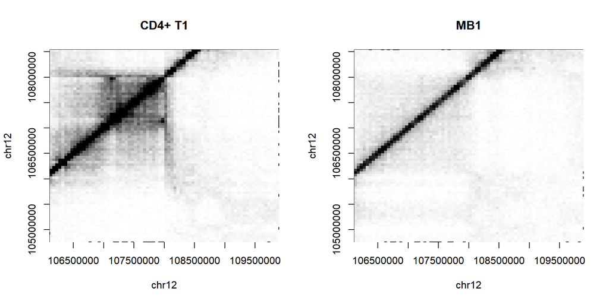

```r
# Setting up the interaction space to be plotted.
chosen.a1 <- anchors(chosen, type="first")
chosen.a2 <- anchors(chosen, type="second")
expanded1 <- resize(chosen.a1, fix="center", width=bin.size*35)
expanded2 <- resize(chosen.a2, fix="center", width=bin.size*35)

cap <- 200
scaled <- (data$totals[c(1,3,5)])/max(data$totals[c(1,3,5)])
cap.scaled<-cap*scaled

# Plotting the WT library.
par(mfrow=c(1,2))
plotPlaid(files[1], first=expanded1, second=expanded2, max.count=cap.scaled[1], width=5e4, param=hs.param, main="CD4+ T1")

plotPlaid(files[3], first=expanded1, second=expanded2, max.count=cap.scaled[3],width=5e4, param=hs.param, main="MB1")
```

Alternatively, users may prefer to use rotPlaid to generate rotated plaid plots. These are more space-efficient and are easier to stack onto other genomic tracks, e.g., for ChIP-seq data. However, rotated plots are only effective for local interactions within a specified region.

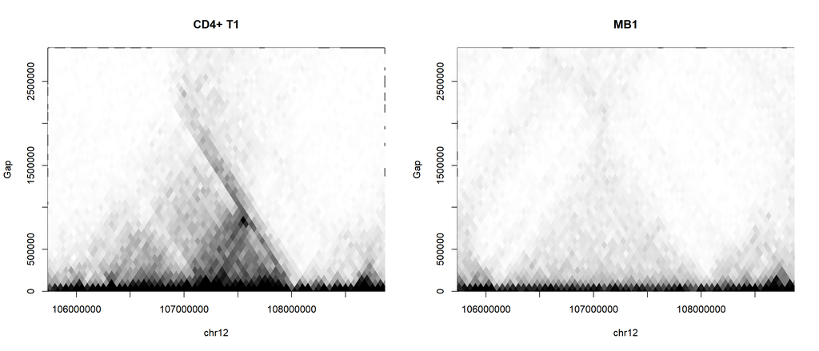

```r
chosen.r <- anchors(chosen, type="second")
end(chosen.r) <- end(anchors(chosen, type="first"))
chosen.r<-resize(chosen.r, width = width(chosen.r)+500e3, fix = "center")

par(mfrow=c(1,2))
rotPlaid(files[1], hs.param, region=chosen.r, width=5e4, main="CD4+ T1", max.count=cap.scaled[1])
rotPlaid(files[3], hs.param, region=chosen.r, width=5e4, main="MB1", max.count=cap.scaled[3])
```

We want to plot the entire chromosome with the DI highlighted in red:

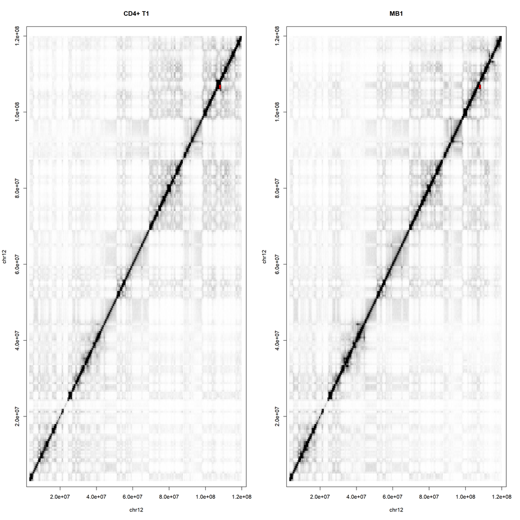

```r
chrom12<-GRanges(c("chr12"), IRanges(c(6e6), c(118e6)))
cap <- 2000
cap.scaled<-cap*scaled

# Plotting the WT library.
par(mfrow=c(1,2))
plotPlaid(files[1], first=chrom12, second=chrom12, max.count=cap.scaled[1],
width=5e5, param=hs.param, main="CD4+ T1")
rect(start(chosen.a1), start(chosen.a2), end(chosen.a1), end(chosen.a2), col="red")

plotPlaid(files[3], first=chrom12, second=chrom12, max.count=cap.scaled[3],
width=5e5, param=hs.param, main="MB1")
rect(start(chosen.a1), start(chosen.a2), end(chosen.a1), end(chosen.a2), col="red")
```

# 7 Exercise: Plot a similar DI from the CD4+ T versus Grans

Now we will plot an interaction from the CD4+ T cell versus Grans comparison on chromosome 12:

```r
chosen <-cluster.CD4T.vs.Gr$interactions[order(results.CD4T.vs.Gr$PValue)][4]
chosen
```

```
## ReverseStrictGInteractions object with 1 interaction and 7 metadata columns:
##       seqnames1             ranges1     seqnames2             ranges2 |
##           <Rle>           <IRanges>         <Rle>           <IRanges> |
##   [1]     chr12 107300096-108300059 ---     chr12 107000031-108000002 |
##        nWindows  logFC.up logFC.down                PValue   direction
##       <integer> <integer>  <integer>             <numeric> <character>
##   [1]        55        54          1 3.77983141198983e-134          up
##                  logFC                FDR
##              <numeric>          <numeric>
##   [1] 3.84831011096834 0.0499761734572314
##   -------
##   regions: 23056 ranges and 0 metadata columns
##   seqinfo: 66 sequences from mm10 genome
```

Now we can use the plotPlaid function with the hdf5s to plot our region of interest in the CD4+ T cells and granulocytes.

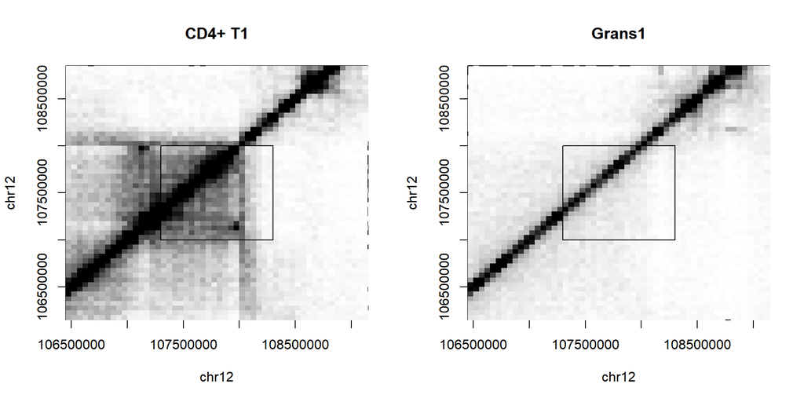

```r
# Setting up the interaction space to be plotted.
chosen.a1 <- anchors(chosen, type="first")
chosen.a2 <- anchors(chosen, type="second")
expanded1 <- resize(chosen.a1, fix="center", width=bin.size*25)
expanded2 <- resize(chosen.a2, fix="center", width=bin.size*25)

cap <- 200
cap.scaled<-cap*scaled

# Plotting the WT library.
par(mfrow=c(1,2))
plotPlaid(files[1], first=expanded1, second=expanded2, max.count=cap.scaled[1], width=5e4, param=hs.param, main="CD4+ T1")
rect(start(chosen.a1), start(chosen.a2), end(chosen.a1), end(chosen.a2))

plotPlaid(files[2], first=expanded1, second=expanded2, max.count=cap.scaled[2],width=5e4, param=hs.param, main="Grans1")
rect(start(chosen.a1), start(chosen.a2), end(chosen.a1), end(chosen.a2))
```

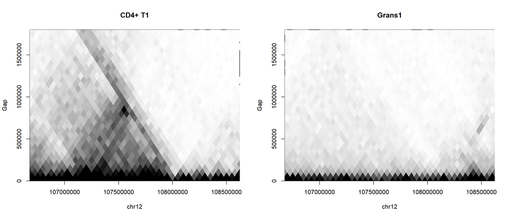

```r
chosen.r <- anchors(chosen, type="second")
end(chosen.r) <- end(anchors(chosen, type="first"))
chosen.r<-resize(chosen.r, width = width(chosen.r)+500e3, fix = "center")

par(mfrow=c(1,2))
rotPlaid(files[1], hs.param, region=chosen.r, width=5e4, main="CD4+ T1", max.count=cap.scaled[1])
rotPlaid(files[2], hs.param, region=chosen.r, width=5e4, main="Grans1", max.count=cap.scaled[2])
```

We want to plot the entire chromosome with the DI highlighted in red:

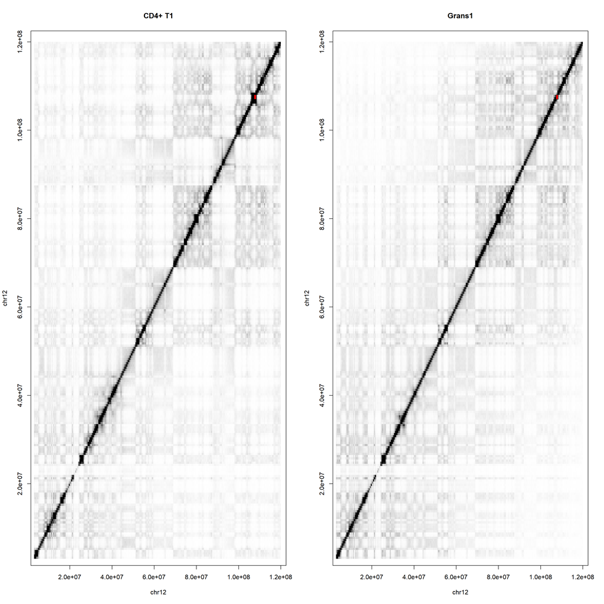

```r
chrom12<-GRanges(c("chr12"), IRanges(c(6e6), c(118e6)))
cap <- 2000
cap.scaled<-cap*scaled

# Plotting the WT library.
par(mfrow=c(1,2))
plotPlaid(files[1], first=chrom12, second=chrom12, max.count=cap.scaled[1],
width=5e5, param=hs.param, main="CD4+ T1")
rect(start(chosen.a1), start(chosen.a2), end(chosen.a1), end(chosen.a2), col="red")

plotPlaid(files[2], first=chrom12, second=chrom12, max.count=cap.scaled[2],
width=5e5, param=hs.param, main="Grans1")
rect(start(chosen.a1), start(chosen.a2), end(chosen.a1), end(chosen.a2), col="red")
```

# 8 Exercise: Perform the differential analysis with the bin.size=1 Mbp data:

I start it off with the filtering…

```r
bin.size <- 1e6
data<-background

direct <- filterDirect(data) #we don't need to use a reference.
direct$threshold
```

```
## [1] -3.708646
```

```r
par(mfrow=c(1,2))
hist(direct$abundances, breaks=100)
abline(v=direct$threshold, lwd=2, col="blue") # Background estimate
abline(v=direct$threshold+log2(8), lwd=2, col="red") # Threshold

high.ab <- direct$abundances > direct$threshold +log2(8)
summary(high.ab)
```

```
##    Mode   FALSE    TRUE
## logical 2768308  145284
```

```r
keep <- high.ab & filterDiag(data, by.diag=1L)
data <- data[keep,]
sum(keep)
```

```
## [1] 140489
```

[figure not shown]

Normalisation:

```r
data.offs <- normOffsets(data, type="loess")
head(assay(data.offs,2))
```

```
##            [,1]      [,2]       [,3]       [,4]        [,5]       [,6]
## [1,] -0.1238577 0.1881279 0.05358190 -0.2094477 -0.05472186 0.14631750
## [2,] -0.1165668 0.2049135 0.12022585 -0.1347853 -0.13008728 0.05630000
## [3,] -0.1244422 0.1831324 0.02853304 -0.2382280 -0.02770574 0.17871050
## [4,] -0.1166615 0.2047455 0.11959382 -0.1354945 -0.12932687 0.05714351
## [5,] -0.1234247 0.1911236 0.06780778 -0.1931057 -0.07021104 0.12781002
## [6,] -0.1241333 0.1858642 0.04234810 -0.2223639 -0.04257353 0.16085846
```

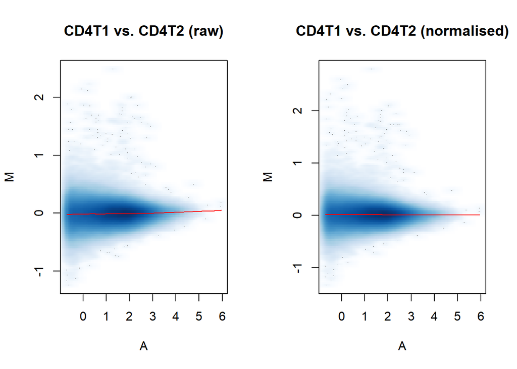

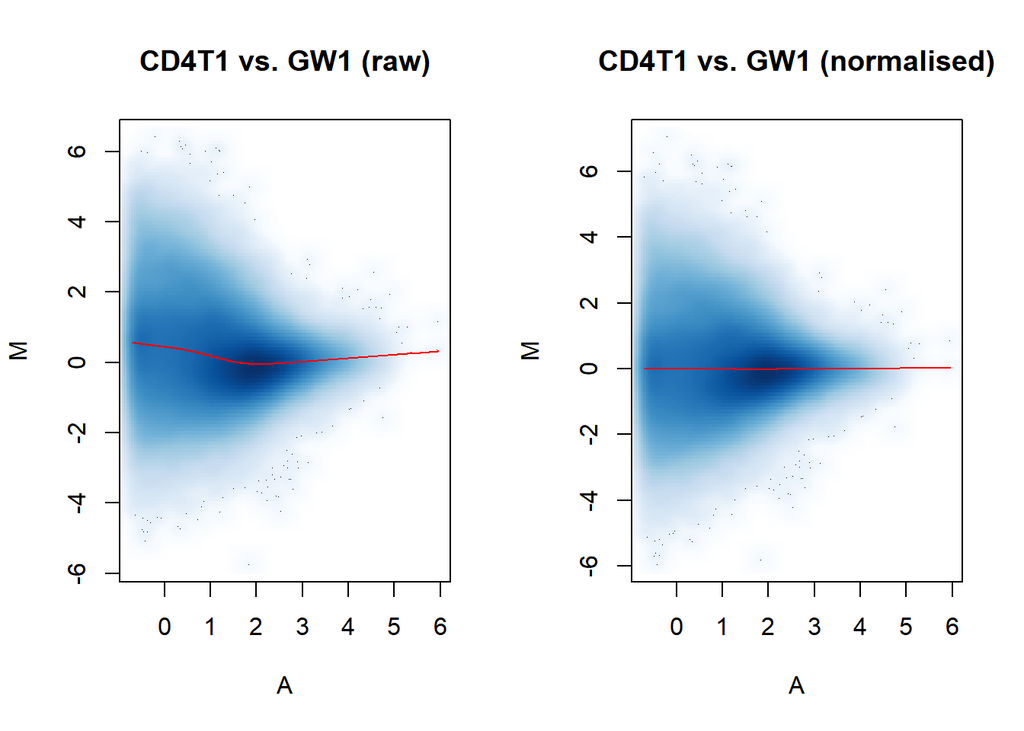

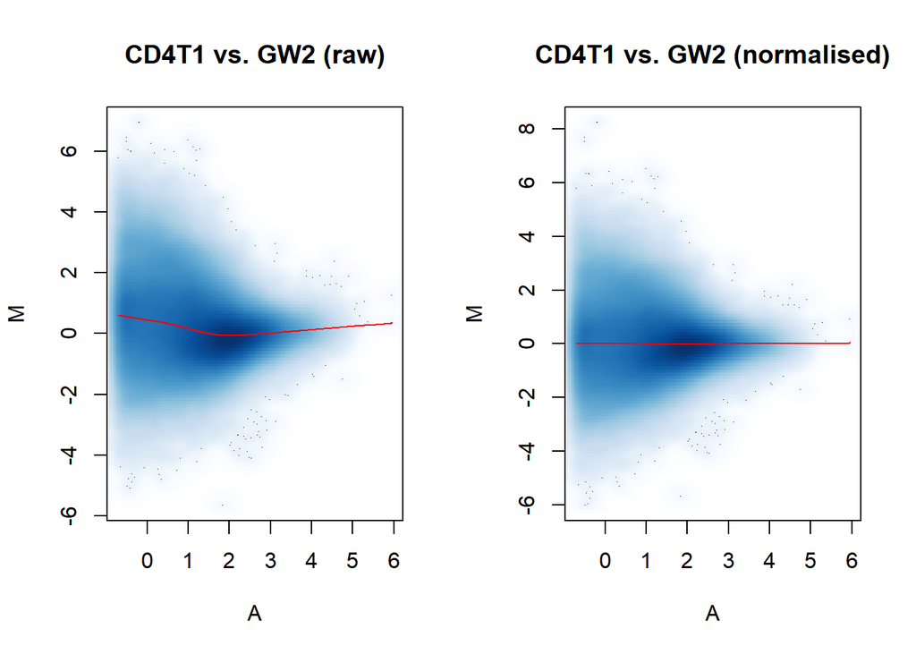

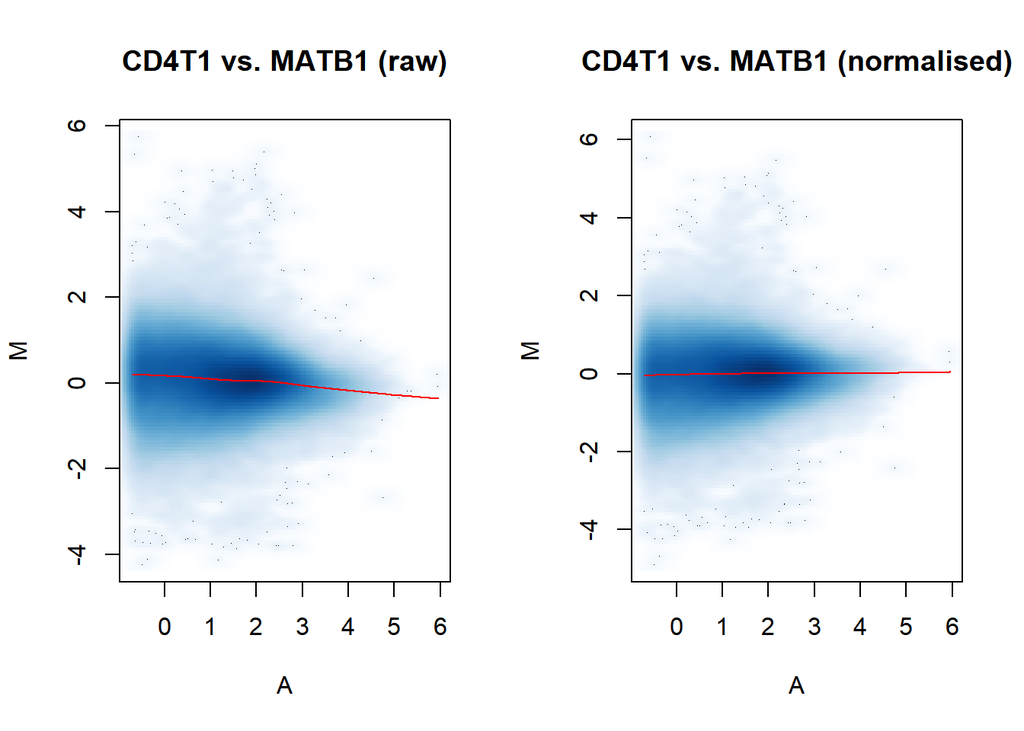

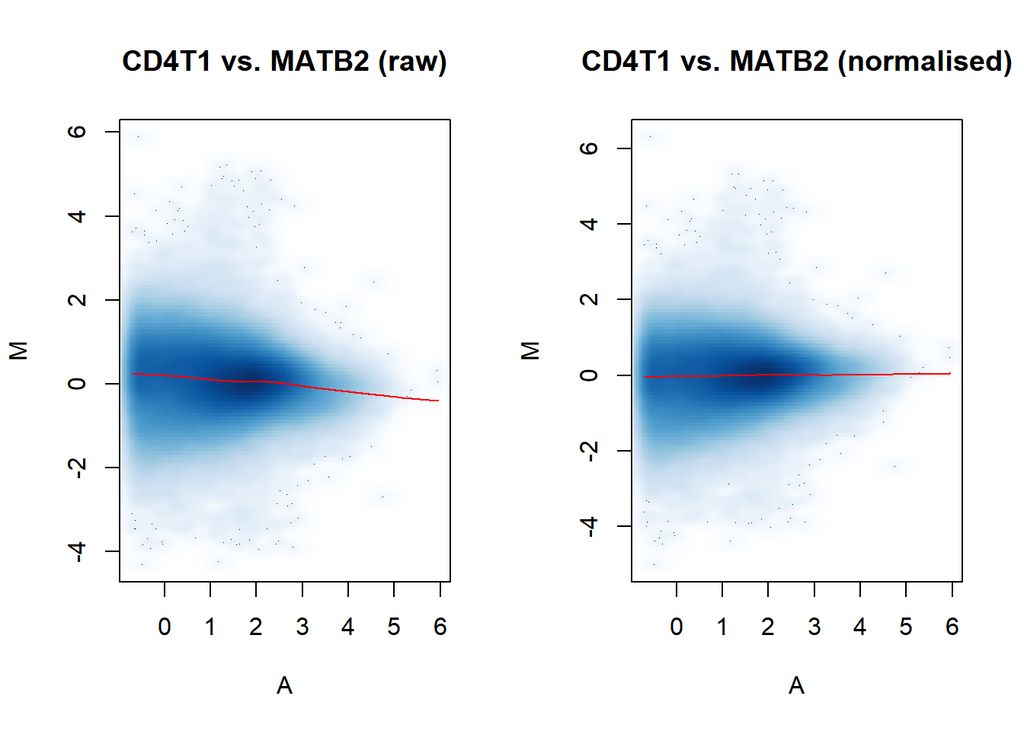

```r
ab <- aveLogCPM(asDGEList(data))
o <- order(ab)
adjc <- cpm(asDGEList(data), log=TRUE)
normc <- log2(assay(data.offs,1)+0.5) - assay(data.offs,2)/log(2)
lib.names <- targets$library
for (lib in c(2:6)) {
    par(mfrow=c(1,2))
    for (mode in c("raw", "normalised")) {
        if (mode=="raw") {
            adj.counts <- adjc
        } else {
            adj.counts <- normc
        }
        mval <- adj.counts[,1]-adj.counts[,lib]
        smoothScatter(ab, mval, xlab="A", ylab="M", cex=0.5, main=sprintf("%s vs. %s (%s)",
                                                                          lib.names[1], lib.names[lib], mode))
        lfit <- loessFit(x=ab, y=mval)
        lines(ab[o], lfit$fitted[o], col="red")
    }
}
```

Create DGEList object:

```r
y <- asDGEList(data.offs)
rownames(y$samples)<-targets$library
colnames(y$counts)<-targets$library
y$samples$group<-targets$group
levels(y$samples$group)<-unique(y$samples$group)
```

MDS plot:

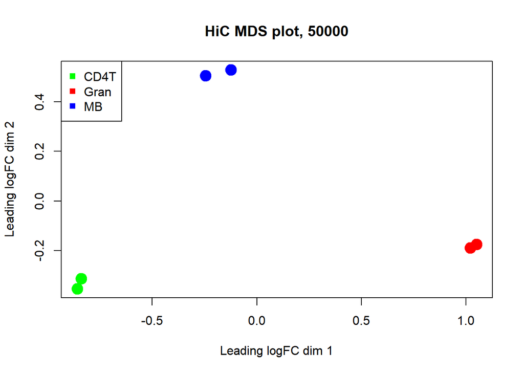

```r
par(mfrow=c(1,1))
group.col <-c("green","green","red","red","blue","blue")
plotMDS(normc, col=group.col,pch = as.numeric(19), top=50000, cex=2, dim.plot = c(1,2), main = "HiC MDS plot, 50000")
legend("topleft", legend = unique(group), col =unique(group.col), pch = as.numeric(15), cex=1.0, title.col = "black")
```

Looking at the dispersion:

```r
design <- model.matrix(~0 + group)
rownames(design) <- targets$library
design
```

```
##       groupCD4T groupGran groupMB
## CD4T1         1         0       0
## CD4T2         1         0       0
## GW1           0         1       0
## GW2           0         1       0
## MATB1         0         0       1
## MATB2         0         0       1
## attr(,"assign")
## [1] 1 1 1
## attr(,"contrasts")
## attr(,"contrasts")$group
## [1] "contr.treatment"
```

```r
dispersion <- estimateDisp(y, design,robust=TRUE)

BCV <- sqrt(dispersion$common.dispersion)
BCV
```

```
## [1] 0.03976761
```

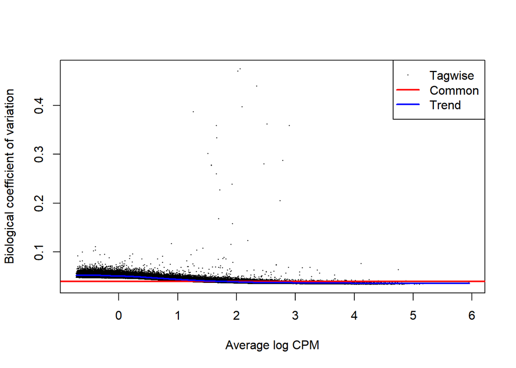

```r
par(mfrow=c(1,1))
plotBCV(dispersion)
```

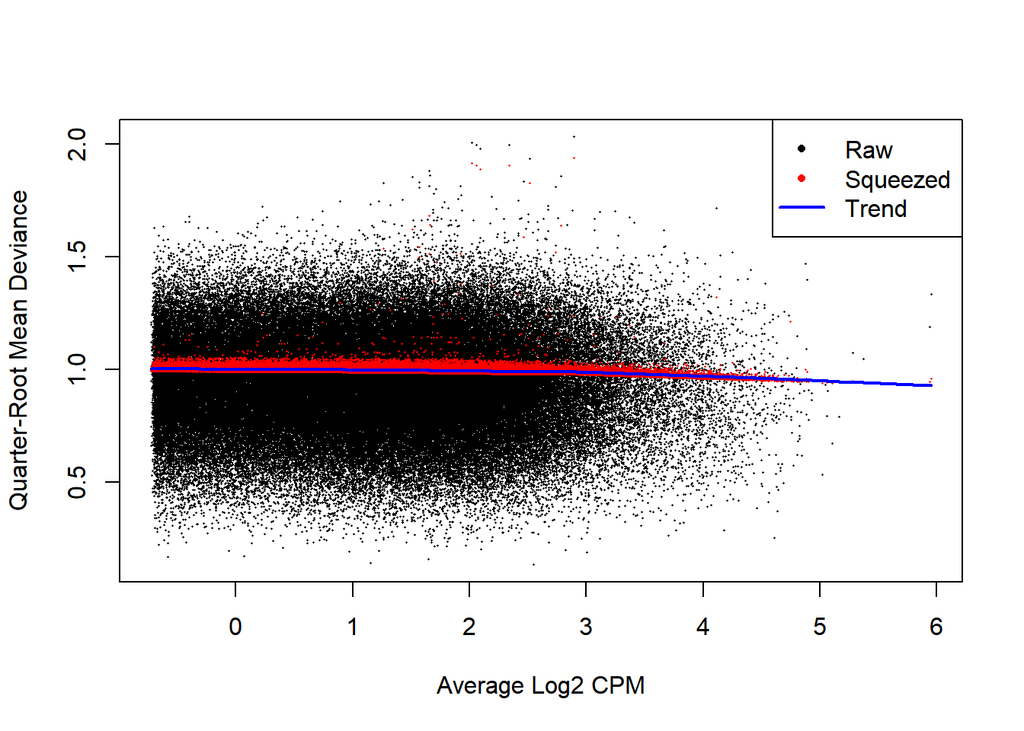

```r
fit <- glmQLFit(dispersion, design, robust=TRUE)
plotQLDisp(fit)
```

Differential analysis:

```r
contrast=makeContrasts(TvsMB=groupCD4T-groupMB,
                       TvsG=groupCD4T-groupGran,
                       MBvsG=groupMB-groupGran, levels=design)
contrast
```

```
##            Contrasts
## Levels      TvsMB TvsG MBvsG
##   groupCD4T     1    1     0
##   groupGran     0   -1    -1
##   groupMB      -1    0     1
```

```r
### Differential interactions between CD4+ T cells and mature B cells
results.CD4T.vs.MB <- glmQLFTest(fit, contrast=contrast[,"TvsMB"])
di.CD4T.vs.MB <- topTags(results.CD4T.vs.MB, sort.by="none", n=Inf)$table
is.di <- di.CD4T.vs.MB$FDR <= 0.05

summary(is.di)
```

```
##    Mode   FALSE    TRUE
## logical   44231   96258
```

```r
cluster.CD4T.vs.MB <- diClusters(data[,c(1,2,5,6)], results.CD4T.vs.MB$table, target=0.05, cluster.args=list(tol=1, upper=bin.size*10))


head(cluster.CD4T.vs.MB$indices[[1]][!is.na(cluster.CD4T.vs.MB$indices[[1]])], n=200)
```

```
##   [1]   1   1   1   1   1   1   1   1   1   1   1   1   1   1   1   1   1
##  [18]   1   1   1   1   1   1   1   1   1   1   1   1   1   1   1   1   1
##  [35]   1   1   1   1   1   1   1   1   2   2   2   2   3   2   2   2   3
##  [52]   3   2   2   2   2   2   2   2   2   2   3   3   3   2   2   2   2
##  [69]   2   2   2   2   2   3   3   3   3   2   2   2   2   3   2 189   2
##  [86]   2   3   3 190 190   2 189   2   3 190 190   2 189   3   3 190   3
## [103]   3   2   3   3   3   3   4   4   4   5   5   5   5   5   5   6   4
## [120]   4   4   5   5   5   5   5   6   6   4   4   4   4   4   4   5   5
## [137]   5   5   5   5   5   5   6   6   4   4   4   4   4   4   4   4   5
## [154]   5   5   5   5   5   5   5   6   4   4   4   4   4   4   4   4   5
## [171]   5   5   5   5   5   5   6   6   6   6   4   4   4   4   4   4   4
## [188]   5   5   5   5   5   5   5   6   6   6   6   6   6
```

```r
tabcom <- combineTests(cluster.CD4T.vs.MB$indices[[1]], results.CD4T.vs.MB$table)
tabbest <- getBestTest(cluster.CD4T.vs.MB$indices[[1]], results.CD4T.vs.MB$table)

tabstats <- data.frame(tabcom[,-5], logFC=tabbest$logFC, FDR=cluster.CD4T.vs.MB$FDR)
results.CD4T.vs.MB <- cbind(as.data.frame(as.data.frame(cluster.CD4T.vs.MB$interactions)[,c(1:3, 6:8)]), tabstats)

is.sig <- !is.na(cluster.CD4T.vs.MB$indices[[1]])
cluster.CD4T.vs.MB$indices[[1]] <- cluster.CD4T.vs.MB$indices[[1]][is.sig]
cluster.CD4T.vs.MB$data <- data[is.sig,c(1,2,5,6)]
mcols(cluster.CD4T.vs.MB$interactions) <- cbind(mcols(cluster.CD4T.vs.MB$interactions), tabstats)

data.frame(Total=nrow(results.CD4T.vs.MB), Down=sum(results.CD4T.vs.MB$direction == "down"), Up=sum(results.CD4T.vs.MB$direction == "up"))
```

```
##   Total Down   Up
## 1  4824 2420 2356
```

```r
stat.CD4T.vs.MB<-results.CD4T.vs.MB[order(results.CD4T.vs.MB$PValue),]
head(stat.CD4T.vs.MB)
```

```
##      seqnames1    start1      end1 seqnames2   start2      end2 nWindows
## 970      chr12 101000151 108999949     chr12 96999869 107000034       39
## 3958      chr6  66999711  78000508      chr6 63000419  72000032       73
## 968      chr12  99000073 108999949     chr12 76999658  86999834       66
## 978      chr12 108999946 120000218     chr12 96999869 107000034       85
## 624      chr11  46999478  53999970     chr11 44999979  51999883       20
## 3957      chr6  66999711  78000508      chr6 52999984  63000422       81
##      logFC.up logFC.down       PValue direction    logFC        FDR
## 970        13         16 1.261513e-54        up 2.749379 0.04995854
## 3958       31         30 5.255600e-50        up 4.287732 0.04995854
## 968        40          1 8.401515e-50        up 4.837752 0.04995854
## 978        55         11 3.996758e-47        up 4.052049 0.04995854
## 624         4          8 6.140313e-46        up 2.837641 0.04995854
## 3957       31         35 6.390525e-45        up 4.647981 0.04995854
```